# Lab 7

Alex Baryiames

08 April, 2019

# For our experiment, an unknown lichen sample was sequenced using ONT’s Minion. Before the conclusions can be drawn, it is important to understand statistics such as the quality, number, and length of the reads. Using various packages, we analyzed the results of our sequencing data.

# Command line

```bash
#!/bin/bash



#Set directory

datapath=/var/lib/MinKNOW/data/rapid_barcode/rapid_barcode/20190325_1834_MN30146_FAK53074_d7dc2974/fastq_pass_demult/barcode03/*.fastq



#Run Nanostat

NanoStat --fastq $datapath



#Run Kraken

minikraken=/usr/share/data/minikraken2

kraken2 --db $minikraken  --threads 12 --use-names --report kreport.tab --fastq-input $datapath > kraken.out

For sorting data: kreport=read.delim('kreport.tab', sep='\t')

head(kreport)



#Run Centrifuge

centdb=/usr/share/data/centrifuge/centref

centrifuge -p 2 -q -x $centdb -U $datapath -S out.centclass --report-file creport.tab --out-fmt tab

For sorting data: creport=read.delim(‘creport.tab’, header=T, sep=’\t’)





#Run NanoPlot

NanoPlot --fastq $datapath --outdir nanoplots



#Run Canu

canu -p lichen -d ecoli-lichen genomeSize=4m maxThreads=12 overlapper=mhap utgReAlign=true -nanopore-raw $datapath &
```

```bash
#!/bin/bash

#Nanostat Data

less /home/abaryiames/Lab_Projects/lichen/NanoStat.txt
```

```
## General summary:
## Mean read length:              230.7
## Mean read quality:               8.3
## Median read length:            150.0
## Median read quality:             8.2
## Number of reads:             4,302.0
## Read length N50:               169.0
## Total bases:               992,311.0
## Number, percentage and megabases of reads above quality cutoffs
## >Q5: 4302 (100.0%) 1.0Mb
## >Q7: 4302 (100.0%) 1.0Mb
## >Q10:    226 (5.3%) 0.2Mb
## >Q12:    4 (0.1%) 0.0Mb
## >Q15:    0 (0.0%) 0.0Mb
## Top 5 highest mean basecall quality scores and their read lengths
## 1:   12.2 (557)
## 2:   12.1 (4051)
## 3:   12.1 (502)
## 4:   12.1 (962)
## 5:   12.0 (151)
## Top 5 longest reads and their mean basecall quality score
## 1:   18653 (10.9)
## 2:   14841 (9.0)
## 3:   14532 (11.3)
## 4:   14296 (9.7)
## 5:   10730 (11.7)
```

The nanostat data gives a general summary of the read statistics. The mean read length was 230 bases, which is very low for nanopore sequencing. This means that most of the data is too small to be accurately matched to the correct organism. However, there was also long read data represented int the data. The top five longest reads were between 18653 and 10730 bases, so those reads could be matched to the correct organism.

```r
library(htmltools)

#setwd("~/Lab_Projects/lichen/nanoplots")

htmltools::includeHTML("~/Lab_Projects/lichen/nanoplots/NanoPlot-report.html")
```

**Summary Statistics**

**Plots**

Histogram of read lengths

Histogram of read lengths after log transformation

Weighted Histogram of read lengths

Weighted Histogram of read lengths after log transformation

Yield by length

Read lengths vs Average read quality plot using dots

Read lengths vs Average read quality plot using a kernel density estimation

# NanoPlot report

## Summary statistics

| **General summary:** |  |
| --- | --- |
| **Mean read length: 230.7** |  |
| **Mean read quality: 8.3** |  |
| **Median read length: 150.0** |  |
| **Median read quality: 8.2** |  |
| **Number of reads: 4,302.0** |  |
| **Read length N50: 169.0** |  |
| **Total bases: 992,311.0** |  |
| **Number, percentage and megabases of reads above quality cutoffs** |  |
| >Q5: | 4302 (100.0%) 1.0Mb |
| >Q7: | 4302 (100.0%) 1.0Mb |
| >Q10: | 226 (5.3%) 0.2Mb |
| >Q12: | 4 (0.1%) 0.0Mb |
| >Q15: | 0 (0.0%) 0.0Mb |
| **Top 5 highest mean basecall quality scores and their read lengths** |  |
| 1: | 12.2 (557) |
| 2: | 12.1 (4051) |
| 3: | 12.1 (502) |
| 4: | 12.1 (962) |
| 5: | 12.0 (151) |
| **Top 5 longest reads and their mean basecall quality score** |  |
| 1: | 18653 (10.9) |
| 2: | 14841 (9.0) |
| 3: | 14532 (11.3) |
| 4: | 14296 (9.7) |
| 5: | 10730 (11.7) |

## Plots

### Histogram of read lengths

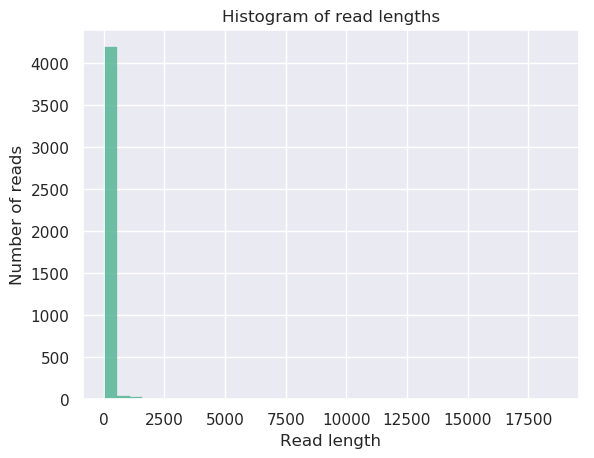

### Histogram of read lengths after log transformation

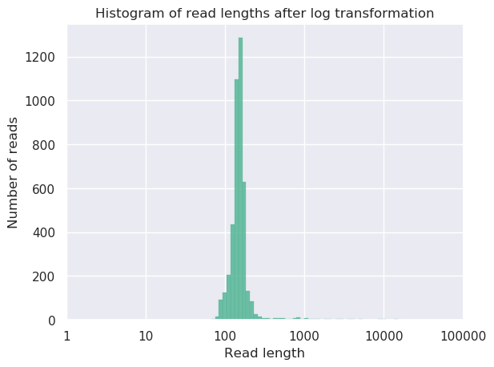

### Weighted Histogram of read lengths

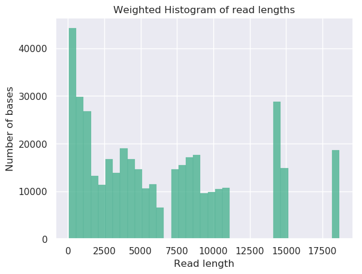

### Weighted Histogram of read lengths after log transformation

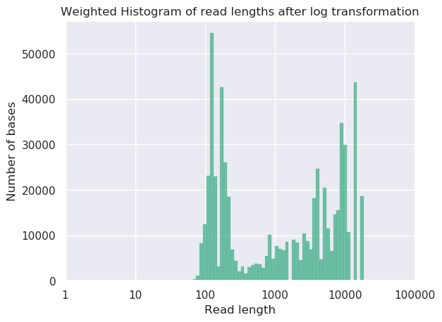

### Yield by length

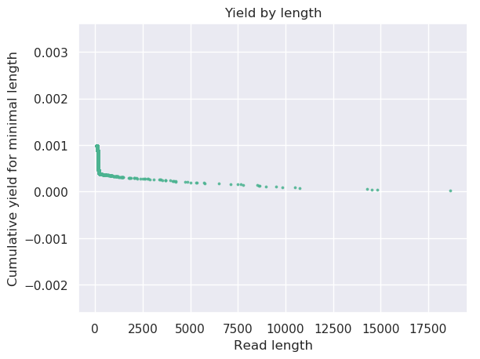

### Read lengths vs Average read quality plot using dots

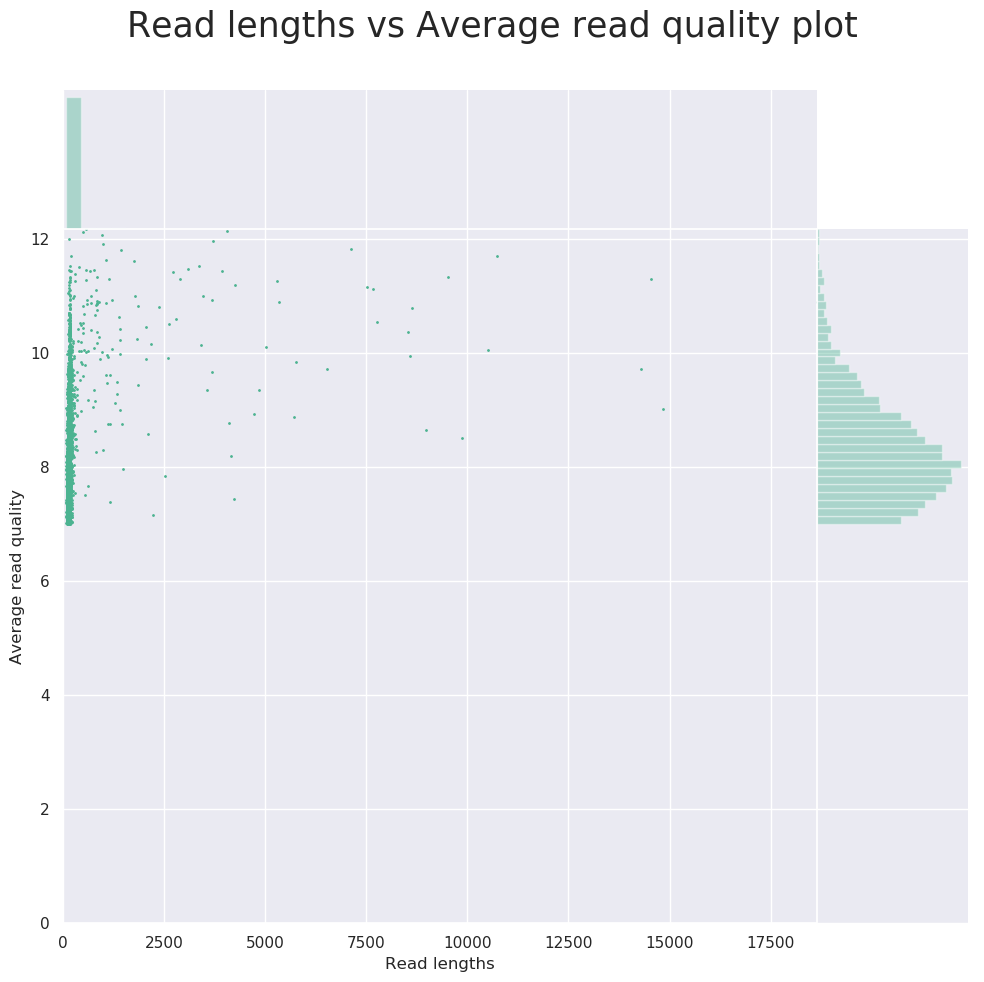